# Project_Full_Code_Notebook_EasyVisa

[figure not shown]

Artificial Intelligence and Machine Learning

Ensemble Techniques and Model Tuning

[figure not shown]

Visa Approval Facilitation

# **Problem Statement**

## Context

Business communities in the United States are facing high demand for human resources, but one of the constant challenges is identifying and attracting the right talent, which is perhaps the most important element in remaining competitive. Companies in the United States look for hard-working, talented, and qualified individuals both locally as well as abroad.

The Immigration and Nationality Act (INA) of the US permits foreign workers to come to the United States to work on either a temporary or permanent basis. The act also protects US workers against adverse impacts on their wages or working conditions by ensuring US employers' compliance with statutory requirements when they hire foreign workers to fill workforce shortages. The immigration programs are administered by the Office of Foreign Labor Certification (OFLC).

OFLC processes job certification applications for employers seeking to bring foreign workers into the United States and grants certifications in those cases where employers can demonstrate that there are not sufficient US workers available to perform the work at wages that meet or exceed the wage paid for the occupation in the area of intended employment.

## Objective

In FY 2016, the OFLC processed 775,979 employer applications for 1,699,957 positions for temporary and permanent labor certifications. This was a nine percent increase in the overall number of processed applications from the previous year. The process of reviewing every case is becoming a tedious task as the number of applicants is increasing every year.

The increasing number of applicants every year calls for a Machine Learning based solution that can help in shortlisting the candidates having higher chances of VISA approval. OFLC has hired the firm EasyVisa for data-driven solutions. You as a data scientist at EasyVisa have to analyze the data provided and, with the help of a classification model:

- Facilitate the process of visa approvals.
- Recommend a suitable profile for the applicants for whom the visa should be certified or denied based on the drivers that significantly influence the case status.

## Data Description

The data contains the different attributes of employee and the employer. The detailed data dictionary is given below.

- case_id: ID of each visa application
- continent: Information of continent the employee
- education_of_employee: Information of education of the employee
- has_job_experience: Does the employee has any job experience? Y= Yes; N = No
- requires_job_training: Does the employee require any job training? Y = Yes; N = No
- no_of_employees: Number of employees in the employer's company
- yr_of_estab: Year in which the employer's company was established
- region_of_employment: Information of foreign worker's intended region of employment in the US.
- prevailing_wage: Average wage paid to similarly employed workers in a specific occupation in the area of intended employment. The purpose of the prevailing wage is to ensure that the foreign worker is not underpaid compared to other workers offering the same or similar service in the same area of employment.
- unit_of_wage: Unit of prevailing wage. Values include Hourly, Weekly, Monthly, and Yearly.
- full_time_position: Is the position of work full-time? Y = Full Time Position; N = Part Time Position
- case_status: Flag indicating if the Visa was certified or denied

## Note: This is a sample solution for the project. Projects will NOT be graded on the basis of how well the submission matches this sample solution. Projects will be graded on the basis of the rubric only.

# **Importing Libraries**

```python
# Installing the libraries with the specified version.
!pip install numpy==2.0.2 pandas==2.2.2 scikit-learn==1.6.1 matplotlib==3.10.0 seaborn==0.13.2 xgboost==3.0.5 -q --user
```

```
   ━━━━━━━━━━━━━━━━━━━━━━━━━━━━━━━━━━━━━━━━ 94.9/94.9 MB 8.8 MB/s eta 0:00:00
```

```python
# Libraries to help with reading and manipulating data
import pandas as pd
import numpy as np

# libaries to help with data visualization
import matplotlib.pyplot as plt
import seaborn as sns

# Library to split data and model tuning, and selection
from sklearn.model_selection import train_test_split
from sklearn.model_selection import StratifiedKFold, GridSearchCV, RandomizedSearchCV

# To oversample and undersample data
from imblearn.over_sampling import SMOTE
from imblearn.under_sampling import RandomUnderSampler

# To build new instance of the model everytime
from sklearn.base import clone

# To build model for prediction
from sklearn.tree import DecisionTreeClassifier
from sklearn.ensemble import RandomForestClassifier
from sklearn.ensemble import BaggingClassifier
from sklearn.ensemble import AdaBoostClassifier
from sklearn.ensemble import GradientBoostingClassifier
from xgboost import XGBClassifier

# To get diferent metric scores
from sklearn.metrics import (
    f1_score,
    accuracy_score,
    recall_score,
    precision_score,
    confusion_matrix,
)

# To suppress unnecessary warnings
import warnings
warnings.filterwarnings("ignore")
```

**Note**: *After running the above cell, kindly restart the notebook kernel and run all cells sequentially from the start again.*

# **Loading Dataset**

```python
# Mount the Google Drive
from google.colab import drive
drive.mount('/content/drive')
```

```python
# Read data and create a data frame
employee_employer_information = pd.read_csv('/content/drive/MyDrive/ColabNotebooks/EasyVisa/EasyVisa.csv')
```

```python
# Copying data to another variable to avoid any changes to original data
data = employee_employer_information.copy()
```

# **Dataset Overview**

#### View the First and Last 5 Rows of the Dataset

```python
# Display the first 5 rows
data.head(5)
```

|  | case_id | continent | education_of_employee | has_job_experience | requires_job_training | no_of_employees | yr_of_estab | region_of_employment | prevailing_wage | unit_of_wage | full_time_position | case_status |
| --- | --- | --- | --- | --- | --- | --- | --- | --- | --- | --- | --- | --- |
| 0 | EZYV01 | Asia | High School | N | N | 14513 | 2007 | West | 592.2029 | Hour | Y | Denied |
| 1 | EZYV02 | Asia | Master's | Y | N | 2412 | 2002 | Northeast | 83425.6500 | Year | Y | Certified |
| 2 | EZYV03 | Asia | Bachelor's | N | Y | 44444 | 2008 | West | 122996.8600 | Year | Y | Denied |
| 3 | EZYV04 | Asia | Bachelor's | N | N | 98 | 1897 | West | 83434.0300 | Year | Y | Denied |
| 4 | EZYV05 | Africa | Master's | Y | N | 1082 | 2005 | South | 149907.3900 | Year | Y | Certified |

```python
# Display last 5 rows from the dataset
data.tail()
```

|  | case_id | continent | education_of_employee | has_job_experience | requires_job_training | no_of_employees | yr_of_estab | region_of_employment | prevailing_wage | unit_of_wage | full_time_position | case_status |
| --- | --- | --- | --- | --- | --- | --- | --- | --- | --- | --- | --- | --- |
| 25475 | EZYV25476 | Asia | Bachelor's | Y | Y | 2601 | 2008 | South | 77092.57 | Year | Y | Certified |
| 25476 | EZYV25477 | Asia | High School | Y | N | 3274 | 2006 | Northeast | 279174.79 | Year | Y | Certified |
| 25477 | EZYV25478 | Asia | Master's | Y | N | 1121 | 1910 | South | 146298.85 | Year | N | Certified |
| 25478 | EZYV25479 | Asia | Master's | Y | Y | 1918 | 1887 | West | 86154.77 | Year | Y | Certified |
| 25479 | EZYV25480 | Asia | Bachelor's | Y | N | 3195 | 1960 | Midwest | 70876.91 | Year | Y | Certified |

#### Understand the Shape of the Dataset

```python
# Get shape of the dataset
(rows, cols) = data.shape

# Print number of rows and columns
print(f'The dataset contains {rows} rows and {cols} columns.')
```

```
The dataset contains 25480 rows and 12 columns.
```

#### Check the Data Types of the Dataset

```python
# Display summary of the dataframe
data.info()
```

```
<class 'pandas.core.frame.DataFrame'>
RangeIndex: 25480 entries, 0 to 25479
Data columns (total 12 columns):
 #   Column                 Non-Null Count  Dtype
---  ------                 --------------  -----
 0   case_id                25480 non-null  object
 1   continent              25480 non-null  object
 2   education_of_employee  25480 non-null  object
 3   has_job_experience     25480 non-null  object
 4   requires_job_training  25480 non-null  object
 5   no_of_employees        25480 non-null  int64
 6   yr_of_estab            25480 non-null  int64
 7   region_of_employment   25480 non-null  object
 8   prevailing_wage        25480 non-null  float64
 9   unit_of_wage           25480 non-null  object
 10  full_time_position     25480 non-null  object
 11  case_status            25480 non-null  object
dtypes: float64(1), int64(2), object(9)
memory usage: 2.3+ MB
```

- There are total 12 columns in the dataset.
> - 9 of them contains string values
> - 2 of them contains int values
> - only 1 colum contains floating values
- None of the column has null values.

#### Statistical Summary of the Dataset

```python
# Discriptive statistics of the dataset
data.describe().T
```

|  | count | mean | std | min | 25% | 50% | 75% | max |
| --- | --- | --- | --- | --- | --- | --- | --- | --- |
| no_of_employees | 25480.0 | 5667.043210 | 22877.928848 | -26.0000 | 1022.00 | 2109.00 | 3504.0000 | 602069.00 |
| yr_of_estab | 25480.0 | 1979.409929 | 42.366929 | 1800.0000 | 1976.00 | 1997.00 | 2005.0000 | 2016.00 |
| prevailing_wage | 25480.0 | 74455.814592 | 52815.942327 | 2.1367 | 34015.48 | 70308.21 | 107735.5125 | 319210.27 |

- The dataset contains 25,480 observations.
- The distribution of number of employees is highly spread out. The median company size is 2,109 employees, minimum value is -26, which is unrealistic and likely represents an invalid/outlier entry, and maximum value is 602,069.
- Company establishment year is relatively stable. The median year is 1997, oldest is 1800, which is possible but looks unusual, and youngest is 2016.
- Prevailing wages show a wide range. The median wage is approximately 70,308, minimum is around 2, which is unrealistic and likely represents an invalid/outlier entry, and maximum is 319,210.

#### Checking for Missing Values

```python
# Check for null
data.isnull().sum()
```

|  | 0 |
| --- | --- |
| case_id | 0 |
| continent | 0 |
| education_of_employee | 0 |
| has_job_experience | 0 |
| requires_job_training | 0 |
| no_of_employees | 0 |
| yr_of_estab | 0 |
| region_of_employment | 0 |
| prevailing_wage | 0 |
| unit_of_wage | 0 |
| full_time_position | 0 |
| case_status | 0 |

**dtype:** int64

- There are no null values in the dataset.

#### Check for Duplicate Records

```python
# Check for duplicate
data.duplicated().sum()
```

```
np.int64(0)
```

- There are no duplicate records in the dataset.

#### Prepare Data for Analysis

```python
# case_id is unique for each visa application and might not add value to modeling
data.drop(["case_id"], axis=1, inplace=True)
```

- `case_id` was removed because it a unique identifier for the visa application and might now add value to the modeling

# **Exploratory Data Analysis (EDA)**

- EDA is an important part of any project involving data.
- It is important to investigate and understand the data better before building a model with it.
- A few questions have been mentioned below which will help you approach the analysis in the right manner and generate insights from the data.
- A thorough analysis of the data, in addition to the questions mentioned below, should be done.

**Leading Questions**

1. What is the distribution of visa case statuses (certified vs. denied)? - **Answered below where I plot the `case_status` barplot**.
2. How does the education level of employees impact visa approval rates? - **Answered below where I plot stacked barplot for `education_of_employee` and `case_status`.**
3. Is there a significant difference in visa approval rates between employees with and without prior job experience? - **Answered below where I plot stacked barplot for `has_job_experience` and `case_status`.**
4. How does the prevailing wage affect visa approval? Do higher wages lead to higher chances of approval? - **Answered below where I plot distribution for `prevailing_wage` and `case_status`.**
5. Do certain regions in the US have higher visa approval rates compared to others? - **Answered below where I plot stacked barplot for `region_of_employment` and `case_status`.**
6. How does the number of employees in a company influence visa approval? Do larger companies have a higher approval rate? - **Answered below where I plot distribution for `no_of_employees` and `case_status`.**
7. Are visa approval rates different across various continents of employees? Which continent has the highest and lowest approval rates? - **Answered below where I plot stacked barplot for `continent` and `case_status`.**

#### Check for Unexpected Values and Correction

```python
# Check unique values from object columns
columns = data.select_dtypes(include=["object"]).columns
for column in columns:
  unique_values = data[column].unique()
  print(f'{column} values = {unique_values}')
```

```
continent values = ['Asia' 'Africa' 'North America' 'Europe' 'South America' 'Oceania']
education_of_employee values = ['High School' "Master's" "Bachelor's" 'Doctorate']
has_job_experience values = ['N' 'Y']
requires_job_training values = ['N' 'Y']
region_of_employment values = ['West' 'Northeast' 'South' 'Midwest' 'Island']
unit_of_wage values = ['Hour' 'Year' 'Week' 'Month']
full_time_position values = ['Y' 'N']
case_status values = ['Denied' 'Certified']
```

The dataset includes multiple categorical features with a small number of unique values:

> - **Continent** has 6 categories: **['Asia' 'Africa' 'North America' 'Europe' 'South America' 'Oceania']**
> - **Education** of employee has 4 levels: **['High School' "Master's" "Bachelor's" 'Doctorate']**
> - **Region of employment** has 5 categories: **['West' 'Northeast' 'South' 'Midwest' 'Island']**
> - **Unit of wage** has 4 categories: **['Hour' 'Year' 'Week' 'Month']**
> - **Has jo experience, reqiore job training, and full time position** features are binary with Y/N values
> - The target variable **Case Status** has two classes: **['Denied' 'Certified']**
> - The **case id** column appears to be a **unique identifier** for each record and does not carry predictive meaning.

```python
# Check unique values from non-object columns
columns = data.select_dtypes(exclude=["object"]).columns
for column in columns:
  min_value = data[column].min()
  max_value = data[column].max()
  print(f'{column} min value = {min_value}, max value = {max_value}')
```

```
no_of_employees min value = -26, max value = 602069
yr_of_estab min value = 1800, max value = 2016
prevailing_wage min value = 2.1367, max value = 319210.27
```

The dataset includes a several of numerical features which have the following ranges:

> - Number of employees ranges from -26 to 602,069 (Negative value indicates invalid/outlier entry)
> - Year of establishment ranges from 1800 to 2016
> - Prevailing wage ranges from 2.1367 to 319,210.27 (very low minimum indicates invalid/outlier entry)

#### Fixing the Negative Values in `no_of_employees` Column

```python
# Find the negateive entries in no_of_employees column
(rows, cols) = data.loc[data["no_of_employees"] < 0].shape
print(f'There are total {rows} entries in the number of emplyees colums that contains negative values.')

# Replace with the absolute values for number of employees
data["no_of_employees"] = abs(data["no_of_employees"])

# Check the negative values again
(rows, cols) = data.loc[data["no_of_employees"] < 0].shape
print(f'There are total {rows} entries in the number of emplyees colums that contains negative values after absolute value replacement.')
```

```
There are total 33 entries in the number of emplyees colums that contains negative values.
There are total 0 entries in the number of emplyees colums that contains negative values after absolute value replacement.
```

### Univariate Analysis

```python
# Function to create histogram and boxplot of a given feature
def histogram_boxplot(data, feature, figsize=(12, 7), kde=False, bins=None, title=None):
    """
    Draws a combined boxplot and histogram for a single numeric feature.

    Parameters
    ----------
    data : pandas.DataFrame
        The dataframe containing the feature.
    feature : str
        Column name of the numeric feature to visualize and summarize.
    figsize : tuple, optional
        Figure size (width, height). Default is (12, 7).
    kde : bool, optional
        Whether to overlay a kernel density estimate on the histogram. Default is False.
    bins : int or sequence, optional
        Number of bins or bin edges for the histogram. If None, seaborn/matplotlib decides.
    title : str, optional
        Title for the overall figure. If None, a default based on the feature name is used.

    Notes
    -----
    This plot is meant to be reviewer-friendly:
      - Boxplot on top shows spread, outliers, and mean (star).
      - Histogram below shows distribution shape.
      - Vertical lines mark mean and median (with legend).
      - Summary statistics (n, mean, median, std, skew) are annotated
        directly on the histogram for quick reference.
    """
    import matplotlib.pyplot as plt
    import seaborn as sns
    import numpy as np

    # Precompute basic summary statistics for annotation
    series = data[feature].dropna()  # drop NA just in case
    mean_val = series.mean()
    median_val = series.median()
    std_val = series.std()
    skew_val = series.skew()
    n = series.shape[0]

    # Create the two vertically stacked subplots (boxplot + histogram)
    fig, (ax_box, ax_hist) = plt.subplots(
        nrows=2,
        sharex=True,
        gridspec_kw={"height_ratios": (0.25, 0.75)},
        figsize=figsize,
    )

    # ----- Boxplot (top) -----
    sns.boxplot(
        data=data,
        x=feature,
        ax=ax_box,
        showmeans=True,         # show mean as a marker
        meanprops={
            "marker": "o",
            "markerfacecolor": "white",
            "markeredgecolor": "black",
            "markersize": 6,
        },
        color="violet",
    )
    ax_box.set_xlabel("")      # Remove x-label on the boxplot (will be on histogram)
    ax_box.set_ylabel("")      # Keep it clean; y-label isn't very meaningful here
    ax_box.set_title("")       # Overall title will go on the figure instead

    # Optional: make the boxplot a bit more compact vertically
    ax_box.grid(axis="x", alpha=0.3)

    # ----- Histogram (bottom) -----
    # NOTE: using `color=` instead of `palette=` is more appropriate for a single numeric feature.
    if bins:
        sns.histplot(
            data=data,
            x=feature,
            kde=kde,
            ax=ax_hist,
            bins=bins,
            color="steelblue",
        )
    else:
        sns.histplot(
            data=data,
            x=feature,
            kde=kde,
            ax=ax_hist,
            color="steelblue",
        )

    # Add vertical lines for mean and median with labels for the legend
    ax_hist.axvline(
        mean_val,
        color="green",
        linestyle="--",
        linewidth=2,
        label=f"Mean = {mean_val:.2f}",
    )
    ax_hist.axvline(
        median_val,
        color="black",
        linestyle="-",
        linewidth=2,
        label=f"Median = {median_val:.2f}",
    )

    # Axis labels and title for the bottom plot
    ax_hist.set_xlabel(feature)
    ax_hist.set_ylabel("Frequency")

    # More informative, reviewer-friendly figure title
    if title is None:
        title = f"Distribution of '{feature}'"
    fig.suptitle(title, fontsize=14, fontweight="bold")

    # Add basic statistics as text inside the histogram area
    # This puts a small stats box in the top-right of the histogram.
    x_min, x_max = ax_hist.get_xlim()
    y_min, y_max = ax_hist.get_ylim()
    text_x = x_min + 0.90 * (x_max - x_min)
    text_y = y_min + 0.95 * (y_max - y_min)

    stats_text = (
        f"n     = {n}\n"
        f"mean  = {mean_val:.2f}\n"
        f"median= {median_val:.2f}\n"
        f"std   = {std_val:.2f}\n"
        f"skew  = {skew_val:.2f}"
    )

    ax_hist.text(
        text_x,
        text_y,
        stats_text,
        ha="left",
        va="top",
        fontsize=10,
        bbox=dict(boxstyle="round", facecolor="white", alpha=0.7),
    )

    # Show legend for mean/median lines
    ax_hist.legend(loc="upper left")

    # Add a light grid for readability
    ax_hist.grid(axis="y", alpha=0.3)

    # Tight layout so labels and title don't overlap
    plt.tight_layout()
    # Adjust top to make room for the suptitle
    plt.subplots_adjust(top=0.90)

    return fig, (ax_box, ax_hist)
```

```python
# Function to create labeled barplots of a given feature
def labeled_barplot(
    data,
    feature,
    perc=False,
    n=None,
    sort="freq",          # "freq" (default) or "alpha"
    title=None,
    rotation=0,
    show_stats=True,
):
    """
    Create a labeled barplot for a categorical feature.

    Parameters
    ----------
    data : pandas.DataFrame
        The dataframe containing the feature.
    feature : str
        Column name of the categorical feature to visualize.
    perc : bool, optional
        If True, annotate bars with percentages.
        If False, annotate bars with counts. Default is False.
    n : int, optional
        Show only the top-n most frequent categories.
        If None, show all categories.
    sort : {"freq", "alpha"}, optional
        Sort order of categories:
            - "freq": descending by count (most frequent first)
            - "alpha": alphabetical by category label
        Default is "freq".
    title : str, optional
        Figure title. If None, a default based on the feature name is used.
    rotation : int or float, optional
        Rotation of x-axis tick labels. Default is 0.
    show_stats : bool, optional
        Whether to show a small stats box (n, missing, unique) on the plot.

    Notes
    -----
    This plot is intended to be reviewer-friendly:
      - Bars are ordered and labeled.
      - Each bar is annotated with count or percentage.
      - A small stats box summarizes sample size and number of levels.
    """
    import matplotlib.pyplot as plt
    import seaborn as sns

    # Work on a Series for convenience
    s = data[feature]

    # Value counts (include NaN as a separate category if present)
    vc = s.value_counts(dropna=False)

    # If we only want top-n categories
    if n is not None:
        vc = vc.head(n)

    # Decide ordering
    if sort == "alpha":
        order = sorted(vc.index, key=lambda x: str(x))
    else:  # "freq" (default)
        order = vc.index

    total_non_missing = s.notna().sum()
    missing = s.isna().sum()
    n_levels = vc.shape[0]

    # Figure size scales with number of categories for readability
    width = max(6, n_levels + 1)
    plt.figure(figsize=(width, 5))

    ax = sns.countplot(
        data=data,
        x=feature,
        order=order,
        palette="Paired",
    )

    # Rotate x-tick labels if needed
    plt.xticks(rotation=rotation, fontsize=11)

    # Axis labels and title
    ax.set_xlabel(feature, fontsize=12)
    ax.set_ylabel("Count", fontsize=12)

    if title is None:
        title = f"Distribution of '{feature}'"
    ax.set_title(title, fontsize=14, fontweight="bold")

    # Annotate each bar with count or percentage
    total_for_perc = len(s)  # use total rows (including missing) for %
    for p in ax.patches:
        count = int(p.get_height())
        if count == 0:
            continue

        if perc:
            pct = 100 * count / total_for_perc
            label = f"{pct:.1f}%"
        else:
            label = f"{count}"

        x = p.get_x() + p.get_width() / 2
        y = p.get_height()

        ax.annotate(
            label,
            (x, y),
            ha="center",
            va="center",
            size=11,
            xytext=(0, 5),
            textcoords="offset points",
        )

    # Small stats box in top-right corner
    if show_stats:
        stats_text = (
            f"n (non-missing) = {total_non_missing}\n"
            f"missing         = {missing}\n"
            f"unique levels   = {n_levels}"
        )
        ax.text(
            0.99,
            0.98,
            stats_text,
            transform=ax.transAxes,   # axis-relative coordinates
            ha="right",
            va="top",
            fontsize=10,
            bbox=dict(boxstyle="round", facecolor="white", alpha=0.9),
        )

    # Add a light grid on y-axis for readability
    ax.grid(axis="y", alpha=0.3)

    plt.tight_layout()
    plt.show()
```

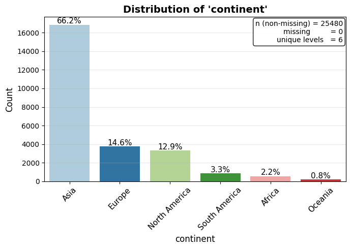

```python
# Continent barplot
labeled_barplot(data, "continent", perc=True, rotation=45)
```

- The `continent` feature has 6 categories with no missing values.
- The distribution is highly imbalanced: Asia dominates (66.2%), followed by Europe (14.6%) and North America (12.9%), while South America (3.3%), Africa (2.2%), and Oceania (0.8%) contribute relatively few records.

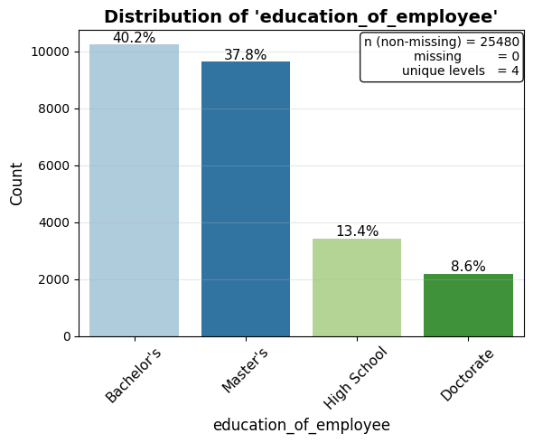

```python
# Emplyee education barplot
labeled_barplot(data, "education_of_employee", perc=True, rotation=45)
```

- The `education_of_employee` feature has 4 categories with no missing values.
- Most applicants have higher education: Bachelor’s (40.2%) and Master’s (37.8%) together make up nearly 78% of the dataset. High School accounts for 13.4%, while Doctorate is the least common at 8.6%.

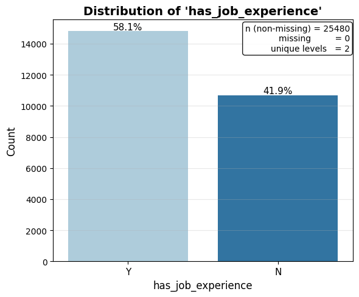

```python
# Job experience barplot
labeled_barplot(data, "has_job_experience", perc=True)
```

- The `has_job_experience` is a binary feature with no missing values.
- A majority of applicants (58.1%) have prior job experience, while 41.9% do not have prior job experience.

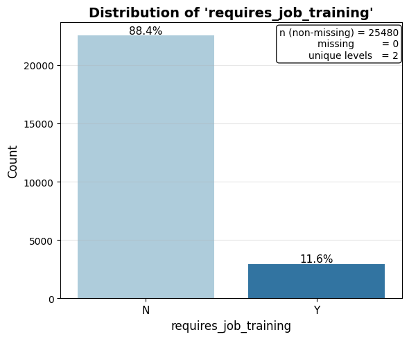

```python
# Requires job training barplot
labeled_barplot(data, "requires_job_training", perc=True)
```

- The `requires_job_training` is a binary feature with no missing values.
- It is strongly imbalanced. Most applicants do not require job training (88.4%), while only 11.6% are marked as require job training.

```
(<Figure size 1200x700 with 2 Axes>,
 (<Axes: >, <Axes: xlabel='no_of_employees', ylabel='Frequency'>))
```

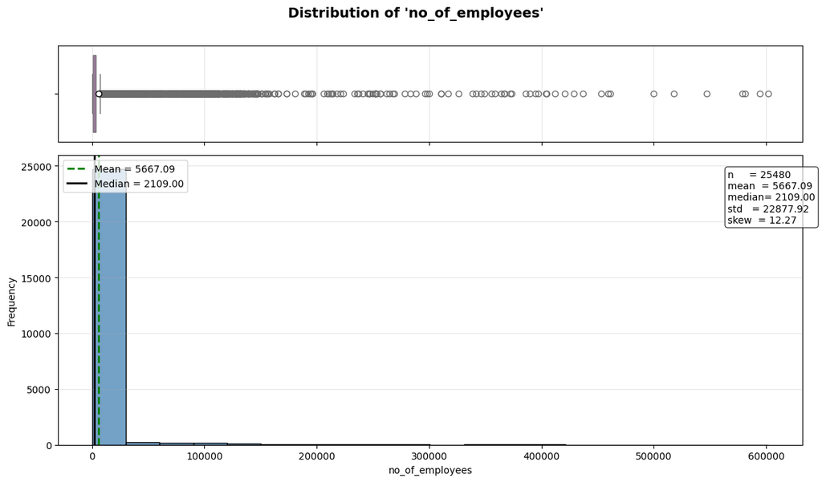

```python
# Number of employees histogram and box plot
histogram_boxplot(data, 'no_of_employees', bins=20)
```

- The `no_of_employees` shows an extremely right-skewed distribution with many outliers. Most employers have relatively small to mid workforce sizes, but a small number of companies have very large employee counts, stretching the range up to 602,069 as shown in the plot.

```
(<Figure size 1200x700 with 2 Axes>,
 (<Axes: >, <Axes: xlabel='yr_of_estab', ylabel='Frequency'>))
```

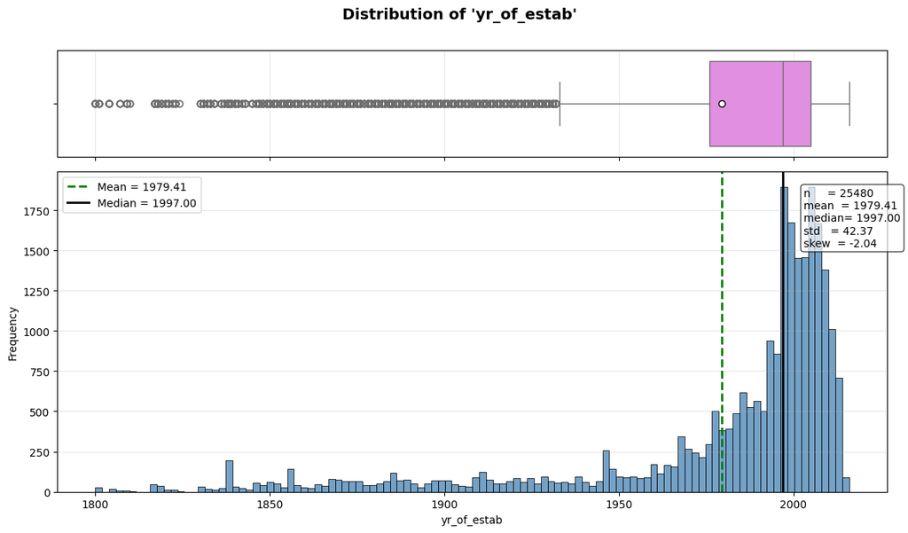

```python
# Year of establishment histogram and box plot
histogram_boxplot(data, 'yr_of_estab')
```

- The `yr_of_estab` feature is negatively skewed (left-skewed), meaning most companies were established in more recent years, with a long tail extending back to earlier years.
- The median establishment year is 1997, while the mean is lower (~1979) due to the presence of very old establishment years (as early as 1800), which appear as outliers in the boxplot. The highest concentration of companies is clustered around the late 1990s to early 2000s.

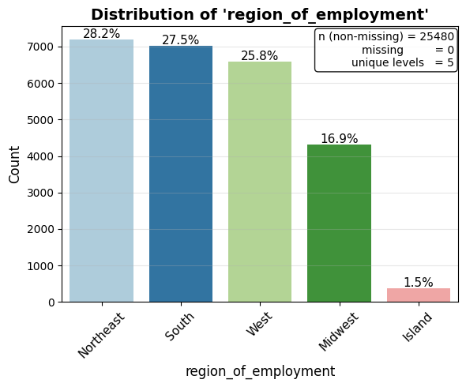

```python
# Region of employment barplot
labeled_barplot(data, "region_of_employment", perc=True, rotation=45)
```

- The `region_of_employment` feature has 5 categories with no missing values.
- The distribution is fairly spread across the major regions: Northeast (28.2%), South (27.5%), and West (25.8%) are the most common and occur at similar rates. Midwest is moderately represented (16.9%), while Island is rare (1.5%).

```
(<Figure size 1200x700 with 2 Axes>,
 (<Axes: >, <Axes: xlabel='prevailing_wage', ylabel='Frequency'>))
```

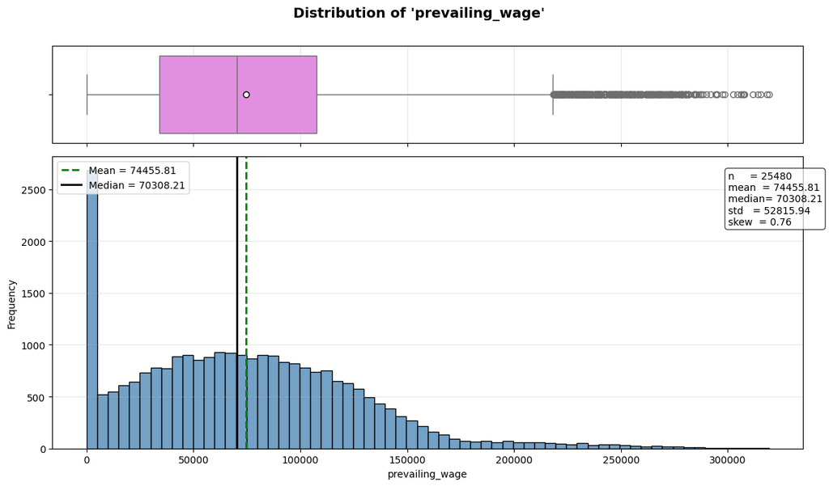

```python
# Prevailing wage histogram and box plot
histogram_boxplot(data, 'prevailing_wage')
```

- The `prevailing_wage` feature has a moderately right-skewed distribution with noticeable high-end outliers. The median wage is approximately 70,308, and the mean is slightly higher (74,456).
- Most wage values are concentrated roughly between 30K and 120K, while a smaller number of cases extend to very high values (up to ~319K), appearing as outliers in the boxplot.
- The plot also shows a spike near very low wages, which likely reflects wages recorded in different units (hour/week/month) or potential invalid entries.

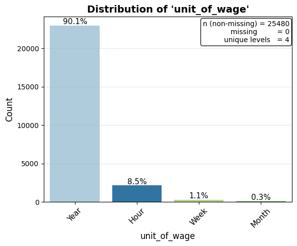

```python
# Unit of wage barplot
labeled_barplot(data, "unit_of_wage", perc=True, rotation=45)
```

- The `unit_of_wage` feature has 4 categories with no missing values.
- It is highly imbalanced. The majority of records report wages on a Yearly basis (90.1%). A smaller portion uses Hourly wages (8.5%), while Weekly (1.1%) and Monthly (0.3%) occur rarely.

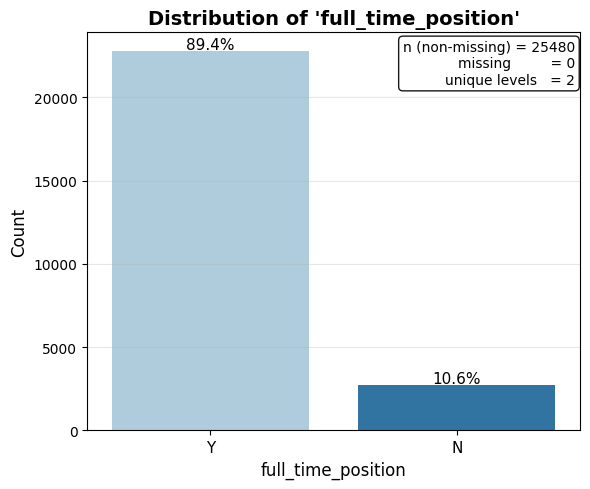

```python
# Fulltime position barplot
labeled_barplot(data, "full_time_position", perc=True)
```

- The `full_time_position` is a binary feature with no missing values.
- It is highly imbalanced. Most applications are for full-time positions (89.4%), while only 10.6% are for part-time positions.

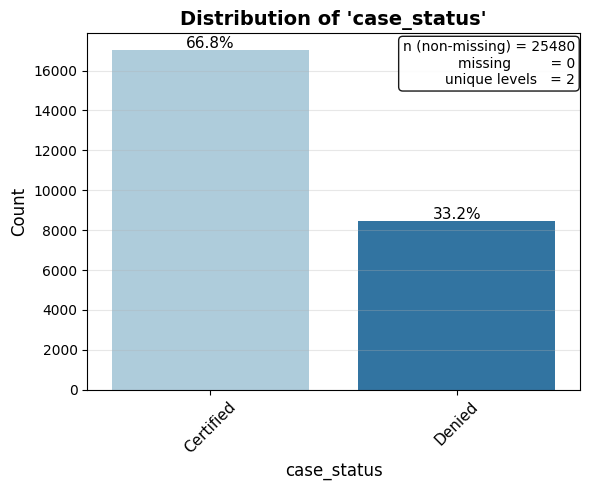

```python
# Case status barplot
labeled_barplot(data, "case_status", perc=True, rotation=45)
```

- The `case_status` is a binary target variable with no missing values.
- The dataset is moderately imbalanced, with Certified cases forming the majority (66.8%) and Denied cases comprising 33.2%.